# Nettoyage des données

Feryal WINDAL

10/4/2019

# Problematic.

You have been contacted by a finance magazine and the editor has sent you a data file on 500 companies and he asks you to make the following graphs: 1- a specific point cloud by industry where we can visualize the income, the expenses and the profit. 2- a point cloud including the trends of the different industries for the expenditure and income variables. 3- a Boxplot showing growth by industry.

As usual, you have to define your working directory. ######################################################################

Vous avez été contacté par un magazine de finance et le directeur de l’édition vous a envoyé un fichier de données sur 500 entreprises et il vous demande de faire les graphiques suivants: 1- un nuage de points spécifique par industire où l’on peu visualiser les revenus, les dépenses et le le profit. 2- un nuage de points incluant les tendances des différentes industries pour les variable dépenses et revenus. 3- un Boxplot montrant la croissance par industie.

Comme d’habitude, il faut définir son répertoire de travail.

```r
setwd("F:/PRO/School JUNIA ISEN/Classes/Data Report, Visualisation/Courses4")
```

We are going to load our dataset which is already in the working directory. We can preview the data with the head function ###################################################################### Nous allons charger notre jeu de données qui se trouve déjà dans le répertoire de travail. Nous pouvons avoir un aperçu des données avec la fonction head

```r
fin=read.csv("Futur500.csv", head=TRUE, sep=",")
head(fin, 10)
```

```
##    ID         Name           Industry Inception Employees State           City
## 1   1     Over-Hex           Software      2006        25    TN       Franklin
## 2   2    Unimattax        IT Services      2009        36    PA Newtown Square
## 3   3     Greenfax             Retail      2012        NA    SC     Greenville
## 4   4    Blacklane        IT Services      2011        66    CA         Orange
## 5   5     Yearflex           Software      2013        45    WI        Madison
## 6   6 Indigoplanet        IT Services      2013        60    NJ      Manalapan
## 7   7      Treslam Financial Services      2009       116    MO        Clayton
## 8   8    Rednimdox       Construction      2013        73    NY       Woodside
## 9   9      Lamtone        IT Services      2009        55    CA      San Ramon
## 10 10    Stripfind Financial Services      2010        25    FL     Boca Raton
##        Revenue          Expenses   Profit Growth
## 1   $9,684,527 1,130,700 Dollars  8553827    19%
## 2  $14,016,543   804,035 Dollars 13212508    20%
## 3   $9,746,272 1,044,375 Dollars  8701897    16%
## 4  $15,359,369 4,631,808 Dollars 10727561    19%
## 5   $8,567,910 4,374,841 Dollars  4193069    19%
## 6  $12,805,452 4,626,275 Dollars  8179177    22%
## 7   $5,387,469 2,127,984 Dollars  3259485    17%
## 8                                      NA
## 9  $11,757,018 6,482,465 Dollars  5274553    30%
## 10 $12,329,371   916,455 Dollars 11412916    20%
```

We can also access the tail of the file (the last lines) with the tail function.

Nous pouvons également accéder à la queue du fichier (les dernières lignes) avec la fonction tail.

```r
tail(fin,10)
```

```
##      ID             Name            Industry Inception Employees State
## 491 491      Comparejson        Construction      2013       125    IL
## 492 492  Pickledcanoeing              Retail      2012        16    OH
## 493 493       Assurehelp         IT Services      2014        10    MN
## 494 494  Shrimpssecurity Government Services      2009       104    DC
## 495 495  Rawfishcomplete  Financial Services      2012       124    CA
## 496 496 Buretteadmirable         IT Services      2009        93    ME
## 497 497 Inventtremendous        Construction      2009        24    MN
## 498 498   Overviewparrot              Retail      2011      7125    TX
## 499 499       Belaguerra         IT Services      2010       140    MI
## 500 500      Allpossible         IT Services      2011        24    CA
##                 City     Revenue          Expenses   Profit Growth
## 491 Glendale Heights $12,359,532 6,527,308 Dollars  5832224    11%
## 492           Medina $11,654,196 6,460,234 Dollars  5193962    10%
## 493      Minneapolis $15,019,551 4,004,040 Dollars 11015511    18%
## 494       Washington  $7,919,278 5,355,504 Dollars  2563774     5%
## 495      Los Angeles $10,624,949 2,951,178 Dollars  7673771    22%
## 496         Portland $15,407,450 2,833,136 Dollars 12574314    25%
## 497         Woodbury  $9,144,857 4,755,995 Dollars  4388862    11%
## 498       Fort Worth $11,134,728 5,152,110 Dollars  5982618    12%
## 499             Troy $17,387,130 1,387,784 Dollars 15999346    23%
## 500      Los Angeles $11,949,706   689,161 Dollars 11260545    24%
```

We can also run the summary function on my dataset to get a little statistic.

Nous pouvons également lancer la fonction summary sur mon jeu de données afin d’obtenir une petite statistique.

```r
summary(fin)
```

```
##        ID            Name             Industry           Inception
##  Min.   :  1.0   Length:500         Length:500         Min.   :1999
##  1st Qu.:125.8   Class :character   Class :character   1st Qu.:2009
##  Median :250.5   Mode  :character   Mode  :character   Median :2011
##  Mean   :250.5                                         Mean   :2010
##  3rd Qu.:375.2                                         3rd Qu.:2012
##  Max.   :500.0                                         Max.   :2014
##                                                        NA's   :1
##    Employees          State               City             Revenue
##  Min.   :   1.00   Length:500         Length:500         Length:500
##  1st Qu.:  27.25   Class :character   Class :character   Class :character
##  Median :  56.00   Mode  :character   Mode  :character   Mode  :character
##  Mean   : 148.61
##  3rd Qu.: 126.00
##  Max.   :7125.00
##  NA's   :2
##    Expenses             Profit            Growth
##  Length:500         Min.   :   12434   Length:500
##  Class :character   1st Qu.: 3272074   Class :character
##  Mode  :character   Median : 6513366   Mode  :character
##                     Mean   : 6539474
##                     3rd Qu.: 9303951
##                     Max.   :19624534
##                     NA's   :2
```

Another function that allows us to see an overview of the data is the str function

Autre fontion qui nous permet de voir une vision d’ensemble des données est la fonction str

```r
str(fin)
```

```
## 'data.frame':    500 obs. of  11 variables:
##  $ ID       : int  1 2 3 4 5 6 7 8 9 10 ...
##  $ Name     : chr  "Over-Hex" "Unimattax" "Greenfax" "Blacklane" ...
##  $ Industry : chr  "Software" "IT Services" "Retail" "IT Services" ...
##  $ Inception: int  2006 2009 2012 2011 2013 2013 2009 2013 2009 2010 ...
##  $ Employees: int  25 36 NA 66 45 60 116 73 55 25 ...
##  $ State    : chr  "TN" "PA" "SC" "CA" ...
##  $ City     : chr  "Franklin" "Newtown Square" "Greenville" "Orange" ...
##  $ Revenue  : chr  "$9,684,527" "$14,016,543" "$9,746,272" "$15,359,369" ...
##  $ Expenses : chr  "1,130,700 Dollars" "804,035 Dollars" "1,044,375 Dollars" "4,631,808 Dollars" ...
##  $ Profit   : int  8553827 13212508 8701897 10727561 4193069 8179177 3259485 NA 5274553 11412916 ...
##  $ Growth   : chr  "19%" "20%" "16%" "19%" ...
```

If not, let’s now look at the rest of the variables in this file. Let us start with the variable “Inception”. It indicates the years of creation of the company. In what follows, we do not need to do arithmetic operations over the years. Same thing with the variable “ID” we don’t need to do arithmetic operations. We are therefore going to transform these two variables into factor.

Sinon regardons maintenant le reste des variables de ce fichier. Prenons pour commencer la variable “Inception”. Elle indique les années de création de l’entreprise. Dans ce qui suit, nous n’avons pas besoin de faire des opérations arithmétiques sur les années. Même chose avec la variable “ID” nous n’avons pas besoin de faire des opérations arithmétiques. Nous allons donc transformer ces deux variables en factor.

```r
fin$ID<-factor(fin$ID)
str(fin)
```

```
## 'data.frame':    500 obs. of  11 variables:
##  $ ID       : Factor w/ 500 levels "1","2","3","4",..: 1 2 3 4 5 6 7 8 9 10 ...
##  $ Name     : chr  "Over-Hex" "Unimattax" "Greenfax" "Blacklane" ...
##  $ Industry : chr  "Software" "IT Services" "Retail" "IT Services" ...
##  $ Inception: int  2006 2009 2012 2011 2013 2013 2009 2013 2009 2010 ...
##  $ Employees: int  25 36 NA 66 45 60 116 73 55 25 ...
##  $ State    : chr  "TN" "PA" "SC" "CA" ...
##  $ City     : chr  "Franklin" "Newtown Square" "Greenville" "Orange" ...
##  $ Revenue  : chr  "$9,684,527" "$14,016,543" "$9,746,272" "$15,359,369" ...
##  $ Expenses : chr  "1,130,700 Dollars" "804,035 Dollars" "1,044,375 Dollars" "4,631,808 Dollars" ...
##  $ Profit   : int  8553827 13212508 8701897 10727561 4193069 8179177 3259485 NA 5274553 11412916 ...
##  $ Growth   : chr  "19%" "20%" "16%" "19%" ...
```

```r
fin$Inception<-factor(fin$Inception)
summary(fin)
```

```
##        ID          Name             Industry           Inception
##  1      :  1   Length:500         Length:500         2011   : 93
##  2      :  1   Class :character   Class :character   2010   : 83
##  3      :  1   Mode  :character   Mode  :character   2012   : 80
##  4      :  1                                         2013   : 69
##  5      :  1                                         2009   : 60
##  6      :  1                                         (Other):114
##  (Other):494                                         NA's   :  1
##    Employees          State               City             Revenue
##  Min.   :   1.00   Length:500         Length:500         Length:500
##  1st Qu.:  27.25   Class :character   Class :character   Class :character
##  Median :  56.00   Mode  :character   Mode  :character   Mode  :character
##  Mean   : 148.61
##  3rd Qu.: 126.00
##  Max.   :7125.00
##  NA's   :2
##    Expenses             Profit            Growth
##  Length:500         Min.   :   12434   Length:500
##  Class :character   1st Qu.: 3272074   Class :character
##  Mode  :character   Median : 6513366   Mode  :character
##                     Mean   : 6539474
##                     3rd Qu.: 9303951
##                     Max.   :19624534
##                     NA's   :2
```

```r
str(fin)
```

```
## 'data.frame':    500 obs. of  11 variables:
##  $ ID       : Factor w/ 500 levels "1","2","3","4",..: 1 2 3 4 5 6 7 8 9 10 ...
##  $ Name     : chr  "Over-Hex" "Unimattax" "Greenfax" "Blacklane" ...
##  $ Industry : chr  "Software" "IT Services" "Retail" "IT Services" ...
##  $ Inception: Factor w/ 16 levels "1999","2000",..: 8 11 14 13 15 15 11 15 11 12 ...
##  $ Employees: int  25 36 NA 66 45 60 116 73 55 25 ...
##  $ State    : chr  "TN" "PA" "SC" "CA" ...
##  $ City     : chr  "Franklin" "Newtown Square" "Greenville" "Orange" ...
##  $ Revenue  : chr  "$9,684,527" "$14,016,543" "$9,746,272" "$15,359,369" ...
##  $ Expenses : chr  "1,130,700 Dollars" "804,035 Dollars" "1,044,375 Dollars" "4,631,808 Dollars" ...
##  $ Profit   : int  8553827 13212508 8701897 10727561 4193069 8179177 3259485 NA 5274553 11412916 ...
##  $ Growth   : chr  "19%" "20%" "16%" "19%" ...
```

Once the transformation of the Inception variable into a factor we can notice by executing the summary function, the frequencies of each modality. Example in 2011 we have 93 companies that were created.

Une fois la transformation de la variable Inception en factor nous pouvons remarquer en executant la fonction summary, les fréquences de chaque modalité. Exemple en 2011 nous avons 93 entreprises qui ont été créées. # Errors with factors

```r
a<-c("12", "13", "14", "12", "12")
a
```

```
## [1] "12" "13" "14" "12" "12"
```

```r
typeof(a)
```

```
## [1] "character"
```

```r
b<-as.numeric(a)
b
```

```
## [1] 12 13 14 12 12
```

```r
typeof(b)
```

```
## [1] "double"
```

This is the easiest way to convert characters to numeric. Now let’s see how to convert a factor to a numeric.

Ceci est la meilleure façon de convertire des caracètes en numérique.

Maintenant regardons comment convertir un factor en numeric.

```r
z<-factor(c("12", "13", "14", "12", "12"))
z
```

```
## [1] 12 13 14 12 12
## Levels: 12 13 14
```

As you can see, z is a vector with 3 levels, 12, 13 and 14. Here, R recognizes these digits as categories or modalities. It can be very confusing and lead to confusion. First reflex is to convert z to a numeric vector. We will try to do the same as before with the vector a and b using the as.numeric function.

Comme vous pouvez le remarquer, z est un vecteur avec 3 levels , 12, 13 et 14. Ici, R reconnait ces chiffres comme des catégories ou des modalités. Cela peut être très déroutant et mener à la confusion. Premier reflexe est de convertir z en un vecteur numeric. Nous allons essayer de faire la même chose que précédemment avec le vecteur a et b en utilisant la fonction as.numeric.

```r
y<-as.numeric(z)
y
```

```
## [1] 1 2 3 1 1
```

```r
typeof(y)
```

```
## [1] "double"
```

We get here a numeric vector with the values 1 2 3 1 1, if we look at the type of y, we get a double type as before. We did the same operations as with a and b but we do not get our vector 12 13 14 12 12. What happened is that we took into account the factorization of the variable rather than the factors (or modalities) themselves. To tell the truth, it assigns the value 1 for the mode 12, the value 2 for the mode 13 and the value 3 for the mode 14. If we look at the type of z:

Nous obtenons ici un vecteur numeric avec les valeurs 1 2 3 1 1, si l’on regarde le type de y, nous obtenons bien un type double comme précédemment. Nous avons fait les mêmes opérations qu’avec a et b mais nous n’obtenons pas notre vecteur 12 13 14 12 12. Ce qui s’est passé, est que nous avons pris en compte la factorisation de la variable plutot que les facteurs (ou modalités) eux mêmes. A vrai dire, il attribu la valeur 1 pour la modalité 12, la valeur 2 pour la modalité 13 et la valeur 3 pour la modalité 14. Si l’on regarde le type de z :

```r
typeof(z)
```

```
## [1] "integer"
```

z is indeed an integer since it attributes integer values to the modalities. When we convert z to a number we get the vector 1 2 3 1 1. This is one of the most common mistakes in programming. To avoid this error, we must convert our vector into a character and then into a numeric

z est bien un entier puisqu’il attribue des valeurs entières aux modalités. Quand nous convertissons z en numéric nous obtenons le vecteur 1 2 3 1 1. Ceci est une des erreurs les plus commises en programmation. Pour éviter cette erreur, il faut convertit notre vecteur en caractère et ensuite en numeric

```r
x=as.numeric(as.character(z))
typeof(x)
```

```
## [1] "double"
```

```r
x
```

```
## [1] 12 13 14 12 12
```

```r
str(fin)
```

```
## 'data.frame':    500 obs. of  11 variables:
##  $ ID       : Factor w/ 500 levels "1","2","3","4",..: 1 2 3 4 5 6 7 8 9 10 ...
##  $ Name     : chr  "Over-Hex" "Unimattax" "Greenfax" "Blacklane" ...
##  $ Industry : chr  "Software" "IT Services" "Retail" "IT Services" ...
##  $ Inception: Factor w/ 16 levels "1999","2000",..: 8 11 14 13 15 15 11 15 11 12 ...
##  $ Employees: int  25 36 NA 66 45 60 116 73 55 25 ...
##  $ State    : chr  "TN" "PA" "SC" "CA" ...
##  $ City     : chr  "Franklin" "Newtown Square" "Greenville" "Orange" ...
##  $ Revenue  : chr  "$9,684,527" "$14,016,543" "$9,746,272" "$15,359,369" ...
##  $ Expenses : chr  "1,130,700 Dollars" "804,035 Dollars" "1,044,375 Dollars" "4,631,808 Dollars" ...
##  $ Profit   : int  8553827 13212508 8701897 10727561 4193069 8179177 3259485 NA 5274553 11412916 ...
##  $ Growth   : chr  "19%" "20%" "16%" "19%" ...
```

Important question, how are we going to remove these characters and turn our variables into numeric?

Before answering this question, we will take a look at the variable “Profit”. It is of type int and that’s perfect. To illustrate what we have studied from the beginning, we will transform this variable into a factor and then transform it back into a numéric (int).

Question importante, comment allons nous supprimer ces caractères et transformer nos variables en numériques ?

Avant de répondre à cette question, nous allons nous intéresser à la variable “Profit”. Elle est de type int et c’est parfait. Pour illustrer ce que nous avons étudié depuis le début, nous allons transformer cette variable en factor et ensuite la retransformer en numéric (int).

```r
fin$Profit<-factor(fin$Profit)
```

```r
str(fin)
```

```
## 'data.frame':    500 obs. of  11 variables:
##  $ ID       : Factor w/ 500 levels "1","2","3","4",..: 1 2 3 4 5 6 7 8 9 10 ...
##  $ Name     : chr  "Over-Hex" "Unimattax" "Greenfax" "Blacklane" ...
##  $ Industry : chr  "Software" "IT Services" "Retail" "IT Services" ...
##  $ Inception: Factor w/ 16 levels "1999","2000",..: 8 11 14 13 15 15 11 15 11 12 ...
##  $ Employees: int  25 36 NA 66 45 60 116 73 55 25 ...
##  $ State    : chr  "TN" "PA" "SC" "CA" ...
##  $ City     : chr  "Franklin" "Newtown Square" "Greenville" "Orange" ...
##  $ Revenue  : chr  "$9,684,527" "$14,016,543" "$9,746,272" "$15,359,369" ...
##  $ Expenses : chr  "1,130,700 Dollars" "804,035 Dollars" "1,044,375 Dollars" "4,631,808 Dollars" ...
##  $ Profit   : Factor w/ 498 levels "12434","46851",..: 342 476 348 420 150 321 125 NA 195 446 ...
##  $ Growth   : chr  "19%" "20%" "16%" "19%" ...
```

```r
head(fin)
```

```
##   ID         Name    Industry Inception Employees State           City
## 1  1     Over-Hex    Software      2006        25    TN       Franklin
## 2  2    Unimattax IT Services      2009        36    PA Newtown Square
## 3  3     Greenfax      Retail      2012        NA    SC     Greenville
## 4  4    Blacklane IT Services      2011        66    CA         Orange
## 5  5     Yearflex    Software      2013        45    WI        Madison
## 6  6 Indigoplanet IT Services      2013        60    NJ      Manalapan
##       Revenue          Expenses   Profit Growth
## 1  $9,684,527 1,130,700 Dollars  8553827    19%
## 2 $14,016,543   804,035 Dollars 13212508    20%
## 3  $9,746,272 1,044,375 Dollars  8701897    16%
## 4 $15,359,369 4,631,808 Dollars 10727561    19%
## 5  $8,567,910 4,374,841 Dollars  4193069    19%
## 6 $12,805,452 4,626,275 Dollars  8179177    22%
```

We notice here that the data of the variable “Profit” are the same as before its transformation into factor.

Now let’s try to transform this variable into numeric:

On remarque ici que les données de la variable “Profit” sont les mêmes qu’avant sa transformation en factor.

Essayons maintenant de transformer cette variable en numérique:

```r
fin$Profit<-as.numeric(fin$Profit)
```

```r
head(fin)
```

```
##   ID         Name    Industry Inception Employees State           City
## 1  1     Over-Hex    Software      2006        25    TN       Franklin
## 2  2    Unimattax IT Services      2009        36    PA Newtown Square
## 3  3     Greenfax      Retail      2012        NA    SC     Greenville
## 4  4    Blacklane IT Services      2011        66    CA         Orange
## 5  5     Yearflex    Software      2013        45    WI        Madison
## 6  6 Indigoplanet IT Services      2013        60    NJ      Manalapan
##       Revenue          Expenses Profit Growth
## 1  $9,684,527 1,130,700 Dollars    342    19%
## 2 $14,016,543   804,035 Dollars    476    20%
## 3  $9,746,272 1,044,375 Dollars    348    16%
## 4 $15,359,369 4,631,808 Dollars    420    19%
## 5  $8,567,910 4,374,841 Dollars    150    19%
## 6 $12,805,452 4,626,275 Dollars    321    22%
```

```r
str(fin)
```

```
## 'data.frame':    500 obs. of  11 variables:
##  $ ID       : Factor w/ 500 levels "1","2","3","4",..: 1 2 3 4 5 6 7 8 9 10 ...
##  $ Name     : chr  "Over-Hex" "Unimattax" "Greenfax" "Blacklane" ...
##  $ Industry : chr  "Software" "IT Services" "Retail" "IT Services" ...
##  $ Inception: Factor w/ 16 levels "1999","2000",..: 8 11 14 13 15 15 11 15 11 12 ...
##  $ Employees: int  25 36 NA 66 45 60 116 73 55 25 ...
##  $ State    : chr  "TN" "PA" "SC" "CA" ...
##  $ City     : chr  "Franklin" "Newtown Square" "Greenville" "Orange" ...
##  $ Revenue  : chr  "$9,684,527" "$14,016,543" "$9,746,272" "$15,359,369" ...
##  $ Expenses : chr  "1,130,700 Dollars" "804,035 Dollars" "1,044,375 Dollars" "4,631,808 Dollars" ...
##  $ Profit   : num  342 476 348 420 150 321 125 NA 195 446 ...
##  $ Growth   : chr  "19%" "20%" "16%" "19%" ...
```

As we can see, Profit is of type numeric but we no longer get the same values. 342 instead of 8553827 … As we saw in the previous example with the variables z and y, R codes the modalities or characteristics by assigning them codes or values.

Comme nous pouvons le voir, Profit est bien de type numeric mais nous n’obtenons plus les mêmes valeurs. 342 au lieu de 8553827… Comme nous l’avions vu dans l’exemple précedent avec les variables z et y, R code les modalités ou les caractéristiques en leur attribuant des codes ou des valeurs.

```r
fin=read.csv("Futur500.csv", head=TRUE, sep=",")
fin$ID<-factor(fin$ID)
fin$Inception<-factor(fin$Inception)
str(fin)
```

```
## 'data.frame':    500 obs. of  11 variables:
##  $ ID       : Factor w/ 500 levels "1","2","3","4",..: 1 2 3 4 5 6 7 8 9 10 ...
##  $ Name     : chr  "Over-Hex" "Unimattax" "Greenfax" "Blacklane" ...
##  $ Industry : chr  "Software" "IT Services" "Retail" "IT Services" ...
##  $ Inception: Factor w/ 16 levels "1999","2000",..: 8 11 14 13 15 15 11 15 11 12 ...
##  $ Employees: int  25 36 NA 66 45 60 116 73 55 25 ...
##  $ State    : chr  "TN" "PA" "SC" "CA" ...
##  $ City     : chr  "Franklin" "Newtown Square" "Greenville" "Orange" ...
##  $ Revenue  : chr  "$9,684,527" "$14,016,543" "$9,746,272" "$15,359,369" ...
##  $ Expenses : chr  "1,130,700 Dollars" "804,035 Dollars" "1,044,375 Dollars" "4,631,808 Dollars" ...
##  $ Profit   : int  8553827 13212508 8701897 10727561 4193069 8179177 3259485 NA 5274553 11412916 ...
##  $ Growth   : chr  "19%" "20%" "16%" "19%" ...
```

# Functions sub() et gsub()

```r
?gsub
```

```
## starting httpd help server ... done
```

As we can read in the description of the function sub (), this function, takes as argument a pattern the element that we want to modify, the replacement is the structure that we want to put and x is the variable where we want to do this replacement.

Comme nous pouvons lire dans le descriptif de la fonction sub(), cette fonction, prend comme argument un pattern l’élément que nous souhaitons modifier, le remplacement est la structure que nous voulons mettre et x est la variable ou l’on souhaite faire ce remplacement.

```r
fin$Expenses<-gsub(" Dollars", "", fin$Expenses)
head(fin)
```

```
##   ID         Name    Industry Inception Employees State           City
## 1  1     Over-Hex    Software      2006        25    TN       Franklin
## 2  2    Unimattax IT Services      2009        36    PA Newtown Square
## 3  3     Greenfax      Retail      2012        NA    SC     Greenville
## 4  4    Blacklane IT Services      2011        66    CA         Orange
## 5  5     Yearflex    Software      2013        45    WI        Madison
## 6  6 Indigoplanet IT Services      2013        60    NJ      Manalapan
##       Revenue  Expenses   Profit Growth
## 1  $9,684,527 1,130,700  8553827    19%
## 2 $14,016,543   804,035 13212508    20%
## 3  $9,746,272 1,044,375  8701897    16%
## 4 $15,359,369 4,631,808 10727561    19%
## 5  $8,567,910 4,374,841  4193069    19%
## 6 $12,805,452 4,626,275  8179177    22%
```

```r
fin$Expenses<-gsub(",","", fin$Expenses)
head(fin)
```

```
##   ID         Name    Industry Inception Employees State           City
## 1  1     Over-Hex    Software      2006        25    TN       Franklin
## 2  2    Unimattax IT Services      2009        36    PA Newtown Square
## 3  3     Greenfax      Retail      2012        NA    SC     Greenville
## 4  4    Blacklane IT Services      2011        66    CA         Orange
## 5  5     Yearflex    Software      2013        45    WI        Madison
## 6  6 Indigoplanet IT Services      2013        60    NJ      Manalapan
##       Revenue Expenses   Profit Growth
## 1  $9,684,527  1130700  8553827    19%
## 2 $14,016,543   804035 13212508    20%
## 3  $9,746,272  1044375  8701897    16%
## 4 $15,359,369  4631808 10727561    19%
## 5  $8,567,910  4374841  4193069    19%
## 6 $12,805,452  4626275  8179177    22%
```

```r
str(fin)
```

```
## 'data.frame':    500 obs. of  11 variables:
##  $ ID       : Factor w/ 500 levels "1","2","3","4",..: 1 2 3 4 5 6 7 8 9 10 ...
##  $ Name     : chr  "Over-Hex" "Unimattax" "Greenfax" "Blacklane" ...
##  $ Industry : chr  "Software" "IT Services" "Retail" "IT Services" ...
##  $ Inception: Factor w/ 16 levels "1999","2000",..: 8 11 14 13 15 15 11 15 11 12 ...
##  $ Employees: int  25 36 NA 66 45 60 116 73 55 25 ...
##  $ State    : chr  "TN" "PA" "SC" "CA" ...
##  $ City     : chr  "Franklin" "Newtown Square" "Greenville" "Orange" ...
##  $ Revenue  : chr  "$9,684,527" "$14,016,543" "$9,746,272" "$15,359,369" ...
##  $ Expenses : chr  "1130700" "804035" "1044375" "4631808" ...
##  $ Profit   : int  8553827 13212508 8701897 10727561 4193069 8179177 3259485 NA 5274553 11412916 ...
##  $ Growth   : chr  "19%" "20%" "16%" "19%" ...
```

As can now be seen, the Expenses variable is of type chr. We will come back later to complete the transformation.

We are now interested in the variable “Revenue” which is a little different than “Expenses”.

Comme on peut le remarquer maintenant la variable Expenses est de type chr. Nous reviendrons par la suite pour terminer la transformation.

Interéssons nous à présent à la variable “Revenue” qui est un peu différente que “Expenses”.

```r
fin$Revenue<-gsub("$","",fin$Revenue)
head(fin)
```

```
##   ID         Name    Industry Inception Employees State           City
## 1  1     Over-Hex    Software      2006        25    TN       Franklin
## 2  2    Unimattax IT Services      2009        36    PA Newtown Square
## 3  3     Greenfax      Retail      2012        NA    SC     Greenville
## 4  4    Blacklane IT Services      2011        66    CA         Orange
## 5  5     Yearflex    Software      2013        45    WI        Madison
## 6  6 Indigoplanet IT Services      2013        60    NJ      Manalapan
##       Revenue Expenses   Profit Growth
## 1  $9,684,527  1130700  8553827    19%
## 2 $14,016,543   804035 13212508    20%
## 3  $9,746,272  1044375  8701897    16%
## 4 $15,359,369  4631808 10727561    19%
## 5  $8,567,910  4374841  4193069    19%
## 6 $12,805,452  4626275  8179177    22%
```

```r
fin$Revenue<-gsub("\\$","",fin$Revenue)
fin$Revenue<-gsub(",","",fin$Revenue)
head(fin)
```

```
##   ID         Name    Industry Inception Employees State           City  Revenue
## 1  1     Over-Hex    Software      2006        25    TN       Franklin  9684527
## 2  2    Unimattax IT Services      2009        36    PA Newtown Square 14016543
## 3  3     Greenfax      Retail      2012        NA    SC     Greenville  9746272
## 4  4    Blacklane IT Services      2011        66    CA         Orange 15359369
## 5  5     Yearflex    Software      2013        45    WI        Madison  8567910
## 6  6 Indigoplanet IT Services      2013        60    NJ      Manalapan 12805452
##   Expenses   Profit Growth
## 1  1130700  8553827    19%
## 2   804035 13212508    20%
## 3  1044375  8701897    16%
## 4  4631808 10727561    19%
## 5  4374841  4193069    19%
## 6  4626275  8179177    22%
```

```r
str(fin)
```

```
## 'data.frame':    500 obs. of  11 variables:
##  $ ID       : Factor w/ 500 levels "1","2","3","4",..: 1 2 3 4 5 6 7 8 9 10 ...
##  $ Name     : chr  "Over-Hex" "Unimattax" "Greenfax" "Blacklane" ...
##  $ Industry : chr  "Software" "IT Services" "Retail" "IT Services" ...
##  $ Inception: Factor w/ 16 levels "1999","2000",..: 8 11 14 13 15 15 11 15 11 12 ...
##  $ Employees: int  25 36 NA 66 45 60 116 73 55 25 ...
##  $ State    : chr  "TN" "PA" "SC" "CA" ...
##  $ City     : chr  "Franklin" "Newtown Square" "Greenville" "Orange" ...
##  $ Revenue  : chr  "9684527" "14016543" "9746272" "15359369" ...
##  $ Expenses : chr  "1130700" "804035" "1044375" "4631808" ...
##  $ Profit   : int  8553827 13212508 8701897 10727561 4193069 8179177 3259485 NA 5274553 11412916 ...
##  $ Growth   : chr  "19%" "20%" "16%" "19%" ...
```

```r
fin$Growth<-gsub("%","",fin$Growth)
head(fin)
```

```
##   ID         Name    Industry Inception Employees State           City  Revenue
## 1  1     Over-Hex    Software      2006        25    TN       Franklin  9684527
## 2  2    Unimattax IT Services      2009        36    PA Newtown Square 14016543
## 3  3     Greenfax      Retail      2012        NA    SC     Greenville  9746272
## 4  4    Blacklane IT Services      2011        66    CA         Orange 15359369
## 5  5     Yearflex    Software      2013        45    WI        Madison  8567910
## 6  6 Indigoplanet IT Services      2013        60    NJ      Manalapan 12805452
##   Expenses   Profit Growth
## 1  1130700  8553827     19
## 2   804035 13212508     20
## 3  1044375  8701897     16
## 4  4631808 10727561     19
## 5  4374841  4193069     19
## 6  4626275  8179177     22
```

```r
str(fin)
```

```
## 'data.frame':    500 obs. of  11 variables:
##  $ ID       : Factor w/ 500 levels "1","2","3","4",..: 1 2 3 4 5 6 7 8 9 10 ...
##  $ Name     : chr  "Over-Hex" "Unimattax" "Greenfax" "Blacklane" ...
##  $ Industry : chr  "Software" "IT Services" "Retail" "IT Services" ...
##  $ Inception: Factor w/ 16 levels "1999","2000",..: 8 11 14 13 15 15 11 15 11 12 ...
##  $ Employees: int  25 36 NA 66 45 60 116 73 55 25 ...
##  $ State    : chr  "TN" "PA" "SC" "CA" ...
##  $ City     : chr  "Franklin" "Newtown Square" "Greenville" "Orange" ...
##  $ Revenue  : chr  "9684527" "14016543" "9746272" "15359369" ...
##  $ Expenses : chr  "1130700" "804035" "1044375" "4631808" ...
##  $ Profit   : int  8553827 13212508 8701897 10727561 4193069 8179177 3259485 NA 5274553 11412916 ...
##  $ Growth   : chr  "19" "20" "16" "19" ...
```

As we can see the 3 variables are of character type, so we can easily convert them to numeric type.

Comme nous pouvons le remarquer les 3 variables sont de type caractère, nous pouvons donc les convertir facilement en type numerique.

```r
fin$Expenses<-as.numeric(fin$Expenses)
fin$Revenue<-as.numeric(fin$Revenue)
fin$Growth<-as.numeric(fin$Growth)
head(fin)
```

```
##   ID         Name    Industry Inception Employees State           City  Revenue
## 1  1     Over-Hex    Software      2006        25    TN       Franklin  9684527
## 2  2    Unimattax IT Services      2009        36    PA Newtown Square 14016543
## 3  3     Greenfax      Retail      2012        NA    SC     Greenville  9746272
## 4  4    Blacklane IT Services      2011        66    CA         Orange 15359369
## 5  5     Yearflex    Software      2013        45    WI        Madison  8567910
## 6  6 Indigoplanet IT Services      2013        60    NJ      Manalapan 12805452
##   Expenses   Profit Growth
## 1  1130700  8553827     19
## 2   804035 13212508     20
## 3  1044375  8701897     16
## 4  4631808 10727561     19
## 5  4374841  4193069     19
## 6  4626275  8179177     22
```

```r
str(fin)
```

```
## 'data.frame':    500 obs. of  11 variables:
##  $ ID       : Factor w/ 500 levels "1","2","3","4",..: 1 2 3 4 5 6 7 8 9 10 ...
##  $ Name     : chr  "Over-Hex" "Unimattax" "Greenfax" "Blacklane" ...
##  $ Industry : chr  "Software" "IT Services" "Retail" "IT Services" ...
##  $ Inception: Factor w/ 16 levels "1999","2000",..: 8 11 14 13 15 15 11 15 11 12 ...
##  $ Employees: int  25 36 NA 66 45 60 116 73 55 25 ...
##  $ State    : chr  "TN" "PA" "SC" "CA" ...
##  $ City     : chr  "Franklin" "Newtown Square" "Greenville" "Orange" ...
##  $ Revenue  : num  9684527 14016543 9746272 15359369 8567910 ...
##  $ Expenses : num  1130700 804035 1044375 4631808 4374841 ...
##  $ Profit   : int  8553827 13212508 8701897 10727561 4193069 8179177 3259485 NA 5274553 11412916 ...
##  $ Growth   : num  19 20 16 19 19 22 17 NA 30 20 ...
```

# The missing data

You will always be faced with missing data again. This is due to certain errors in data entry or manipulation. To remedy this, several options are available to us: 1- Predict missing data with 100% accuracy. For example you can fill in fields if you are on information. In our example, if we have the information on the income and the expenses, it would be simple to deduct the profit. Or if we have the name of a city and we are missing the state (for the US) department, it is also easy to fill in the missing information.

2- Leave the cell (or information) empty. This is in the case where the field or the variable is not important, in this case, having missing information is not important. However, there are algorithms that allow you to manage these empty fields.

3- delete the entire line. This is a method that is not recommended since our study ends up with a small sample. But sometimes we only have that option.

4-Replace with the mean or the median It is the most popular method in data science. It is better to replace with the median than the mean since the median is not affected by extreme values.

5- Complete using predictive models. We can explore the correlation or the regression between two variables, define the line and thus the missing values.

Vous serez plus jamais confrontés aux données manquantes. Cela est du à cause de certaines erreurs de saisie ou de manipulation des données. Pour remédier a cela, plusieurs options s’offrent à nous : 1- Prédir les données manquantes avec 100% de précision. Par exemple vous pouvez remplir des champs si vous êtes sur de l’information. Dans notre exemple, si nous avons l’information sur la recette et les dépenses, il serait simple de déduir le profit. Ou si nous avons le nom d’une ville et qu’il nous manque l’état (pour les USA) le département, il est aussi facile de remplir l’information manquante.

2- Laisser la cellule (ou l’information) vide. C’est dans le cas ou le champ ou la variable n’est pas importante, dans ce cas, avoir des informations manquantes ce n’est pas important. Il existe néanmoins des algorithmes qui permettent de gérer ces champs vide.

3- supprimer la ligne entière. C’est une méthode qui n’est pas recommandée puisque notre étude se retrouve avec un petit échantillon. Mais des fois nous n’avons que cette option.

4-Replacer avec la moyenne ou la médiane C’est la méthode la plus populaire en data science. Il est préférable de remplacer avec la médiane que la moyenne puisque la médiane n’est pas affectée par les valeurs extrèmes.

5- Remplir en utilisant les modèles prédictifs. Nous pouvons explorer la corrélation ou la régression entre deux variables, définir la droite et ainsi les valeurs manquantes.

# NA values

I suggest you to read about NA by typing the command

Je vous invite à lire sur NA en tapant la commande

```r
?NA
```

As you can read, this is a logical variable. Let’s take an example : Consider the following proposition: Jean has a car. This proposition is either true or false and if we do not know it in R, it is NA. ###################################################################### Comme vous pouvez le lire, il s’agit d’une variable logique. Prenons un exemple : Soit la proposition suivante : Jean a une voiture . Cette proposition est soit vraie, soit fausse et si l’on en sait pas en R, c’est du NA.

```r
TRUE #1
```

```
## [1] TRUE
```

```r
FALSE #0
```

```
## [1] FALSE
```

```r
NA
```

```
## [1] NA
```

```r
TRUE ==FALSE
```

```
## [1] FALSE
```

```r
TRUE==5
```

```
## [1] FALSE
```

```r
TRUE==1
```

```
## [1] TRUE
```

```r
FALSE==4
```

```
## [1] FALSE
```

```r
FALSE==FALSE
```

```
## [1] TRUE
```

```r
FALSE==0
```

```
## [1] TRUE
```

```r
NA==TRUE
```

```
## [1] NA
```

```r
NA==FALSE
```

```
## [1] NA
```

```r
NA==15
```

```
## [1] NA
```

```r
15==NA
```

```
## [1] NA
```

```r
NA==NA
```

```
## [1] NA
```

NA tells us that we are comparing a missing value to something, but we do not know the value of the missing value. That’s why we get NA every time.

NA nous indique que nous comparons une valeur manquante à quelque chose, or nous ne connaissant pas la valeur de la valeur manquante. C’est pour cette raison que nous obtenons NA à chaque fois.

```r
head(fin,24)
```

```
##    ID            Name            Industry Inception Employees State
## 1   1        Over-Hex            Software      2006        25    TN
## 2   2       Unimattax         IT Services      2009        36    PA
## 3   3        Greenfax              Retail      2012        NA    SC
## 4   4       Blacklane         IT Services      2011        66    CA
## 5   5        Yearflex            Software      2013        45    WI
## 6   6    Indigoplanet         IT Services      2013        60    NJ
## 7   7         Treslam  Financial Services      2009       116    MO
## 8   8       Rednimdox        Construction      2013        73    NY
## 9   9         Lamtone         IT Services      2009        55    CA
## 10 10       Stripfind  Financial Services      2010        25    FL
## 11 11 Canecorporation              Health      2012         6
## 12 12        Mattouch         IT Services      2013         6    WA
## 13 13       Techdrill              Health      2009         9    MS
## 14 14        Techline                          2006        65    CA
```

[output cut: 35 more lines]

```r
complete.cases(fin)
```

```
##   [1]  TRUE  TRUE FALSE  TRUE  TRUE  TRUE  TRUE FALSE  TRUE  TRUE  TRUE  TRUE
##  [13]  TRUE  TRUE  TRUE  TRUE FALSE  TRUE  TRUE  TRUE  TRUE FALSE  TRUE  TRUE
##  [25]  TRUE  TRUE  TRUE  TRUE  TRUE  TRUE  TRUE  TRUE  TRUE  TRUE  TRUE  TRUE
##  [37]  TRUE  TRUE  TRUE  TRUE  TRUE  TRUE  TRUE FALSE  TRUE  TRUE  TRUE  TRUE
##  [49]  TRUE  TRUE  TRUE  TRUE  TRUE  TRUE  TRUE  TRUE  TRUE  TRUE  TRUE  TRUE
##  [61]  TRUE  TRUE  TRUE  TRUE  TRUE  TRUE  TRUE  TRUE  TRUE  TRUE  TRUE  TRUE
##  [73]  TRUE  TRUE  TRUE  TRUE  TRUE  TRUE  TRUE  TRUE  TRUE  TRUE  TRUE  TRUE
##  [85]  TRUE  TRUE  TRUE  TRUE  TRUE  TRUE  TRUE  TRUE  TRUE  TRUE  TRUE  TRUE
##  [97]  TRUE  TRUE  TRUE  TRUE  TRUE  TRUE  TRUE  TRUE  TRUE  TRUE  TRUE  TRUE
## [109]  TRUE  TRUE  TRUE  TRUE  TRUE  TRUE  TRUE  TRUE  TRUE  TRUE  TRUE  TRUE
## [121]  TRUE  TRUE  TRUE  TRUE  TRUE  TRUE  TRUE  TRUE  TRUE  TRUE  TRUE  TRUE
## [133]  TRUE  TRUE  TRUE  TRUE  TRUE  TRUE  TRUE  TRUE  TRUE  TRUE  TRUE  TRUE
## [145]  TRUE  TRUE  TRUE  TRUE  TRUE  TRUE  TRUE  TRUE  TRUE  TRUE  TRUE  TRUE
## [157]  TRUE  TRUE  TRUE  TRUE  TRUE  TRUE  TRUE  TRUE  TRUE  TRUE  TRUE  TRUE
## [169]  TRUE  TRUE  TRUE  TRUE  TRUE  TRUE  TRUE  TRUE  TRUE  TRUE  TRUE  TRUE
```

[output cut: 27 more lines]

The complete.cases (end) function will cycle through the file and return a vector with TRUE and FALSE. TRUE indicates that the row has no missing data. FALSE indicates the row with missing data.

La fonction complete.cases(fin) va parcourir le fichier et renvoyer un vecteur avec TRUE et FALSE. TRUE indique que la ligne n’a pas de données manquantes. FALSE indique la ligne avec des données manquantes.

```r
fin[complete.cases(fin),]
```

```
##      ID                 Name            Industry Inception Employees State
## 1     1             Over-Hex            Software      2006        25    TN
## 2     2            Unimattax         IT Services      2009        36    PA
## 4     4            Blacklane         IT Services      2011        66    CA
## 5     5             Yearflex            Software      2013        45    WI
## 6     6         Indigoplanet         IT Services      2013        60    NJ
## 7     7              Treslam  Financial Services      2009       116    MO
## 9     9              Lamtone         IT Services      2009        55    CA
## 10   10            Stripfind  Financial Services      2010        25    FL
## 11   11      Canecorporation              Health      2012         6
## 12   12             Mattouch         IT Services      2013         6    WA
## 13   13            Techdrill              Health      2009         9    MS
## 14   14             Techline                          2006        65    CA
## 15   15              Cityace                          2010        25    CO
## 16   16       Kayelectronics              Health      2009       687    NC
```

[output cut: 975 more lines]

```r
fin
```

```
##      ID                 Name            Industry Inception Employees State
## 1     1             Over-Hex            Software      2006        25    TN
## 2     2            Unimattax         IT Services      2009        36    PA
## 3     3             Greenfax              Retail      2012        NA    SC
## 4     4            Blacklane         IT Services      2011        66    CA
## 5     5             Yearflex            Software      2013        45    WI
## 6     6         Indigoplanet         IT Services      2013        60    NJ
## 7     7              Treslam  Financial Services      2009       116    MO
## 8     8            Rednimdox        Construction      2013        73    NY
## 9     9              Lamtone         IT Services      2009        55    CA
## 10   10            Stripfind  Financial Services      2010        25    FL
## 11   11      Canecorporation              Health      2012         6
## 12   12             Mattouch         IT Services      2013         6    WA
## 13   13            Techdrill              Health      2009         9    MS
## 14   14             Techline                          2006        65    CA
```

[output cut: 987 more lines]

This instruction returns a data frame with only the rows or there is no missing data. If we rather want a data frame with only the missing data:

Cette instruction retourne un data frame avec seulement les lignes ou il n’y a pas de données manquantes. Si l’on souhaite plutot un data frame avec que les données manquantes:

```r
!complete.cases(fin)
```

```
##   [1] FALSE FALSE  TRUE FALSE FALSE FALSE FALSE  TRUE FALSE FALSE FALSE FALSE
##  [13] FALSE FALSE FALSE FALSE  TRUE FALSE FALSE FALSE FALSE  TRUE FALSE FALSE
##  [25] FALSE FALSE FALSE FALSE FALSE FALSE FALSE FALSE FALSE FALSE FALSE FALSE
##  [37] FALSE FALSE FALSE FALSE FALSE FALSE FALSE  TRUE FALSE FALSE FALSE FALSE
##  [49] FALSE FALSE FALSE FALSE FALSE FALSE FALSE FALSE FALSE FALSE FALSE FALSE
##  [61] FALSE FALSE FALSE FALSE FALSE FALSE FALSE FALSE FALSE FALSE FALSE FALSE
##  [73] FALSE FALSE FALSE FALSE FALSE FALSE FALSE FALSE FALSE FALSE FALSE FALSE
##  [85] FALSE FALSE FALSE FALSE FALSE FALSE FALSE FALSE FALSE FALSE FALSE FALSE
##  [97] FALSE FALSE FALSE FALSE FALSE FALSE FALSE FALSE FALSE FALSE FALSE FALSE
## [109] FALSE FALSE FALSE FALSE FALSE FALSE FALSE FALSE FALSE FALSE FALSE FALSE
## [121] FALSE FALSE FALSE FALSE FALSE FALSE FALSE FALSE FALSE FALSE FALSE FALSE
## [133] FALSE FALSE FALSE FALSE FALSE FALSE FALSE FALSE FALSE FALSE FALSE FALSE
## [145] FALSE FALSE FALSE FALSE FALSE FALSE FALSE FALSE FALSE FALSE FALSE FALSE
## [157] FALSE FALSE FALSE FALSE FALSE FALSE FALSE FALSE FALSE FALSE FALSE FALSE
## [169] FALSE FALSE FALSE FALSE FALSE FALSE FALSE FALSE FALSE FALSE FALSE FALSE
```

[output cut: 27 more lines]

```r
fin[!complete.cases(fin),]
```

```
##      ID        Name           Industry Inception Employees State       City
## 3     3    Greenfax             Retail      2012        NA    SC Greenville
## 8     8   Rednimdox       Construction      2013        73    NY   Woodside
## 17   17     Ganzlax        IT Services      2011        75    NJ     Iselin
## 22   22  Lathotline             Health      <NA>       103    VA     McLean
## 44   44   Ganzgreen       Construction      2010       224    TN   Franklin
## 332 332 Westminster Financial Services      2010        NA    MI       Troy
##      Revenue Expenses   Profit Growth
## 3    9746272  1044375  8701897     16
## 8         NA       NA       NA     NA
## 17  14001180       NA 11901180     18
## 22   9418303  7567233  1851070      2
## 44        NA       NA       NA      9
## 332 11861652  5245126  6616526     15
```

We can compare this result with the excel file and see that there are more than 6 lines with missing data, just complete.cases will look for the lines with NA and does not count the lines where the fields are empty.

To remedy this problem we have to go back to the beginning with our read.csv function.

Nous pouvons comparer ce résultat avec le fichier excel et constater qu’il y a plus de 6 lignes avec des données manquantes, simplement complete.cases va chercher les lignes avec NA et ne comptabilise pas les lignes où les champs sont vides.

Pour remédier à ce problème nous devons revenir dès le début avec notre fonction read.csv.

```r
fin=read.csv("Futur500.csv", head=TRUE, sep=",", na.strings = c(""))


fin$ID<-factor(fin$ID)
fin$Inception<-factor(fin$Inception)
fin$Expenses<-gsub(" Dollars", "", fin$Expenses)
fin$Expenses<-gsub(",","", fin$Expenses)
fin$Revenue<-gsub("\\$","",fin$Revenue)
fin$Revenue<-gsub(",","",fin$Revenue)
fin$Growth<-gsub("%","",fin$Growth)
fin$Expenses<-as.numeric(fin$Expenses)
fin$Revenue<-as.numeric(fin$Revenue)
fin$Growth<-as.numeric(fin$Growth)
str(fin)
```

```
## 'data.frame':    500 obs. of  11 variables:
##  $ ID       : Factor w/ 500 levels "1","2","3","4",..: 1 2 3 4 5 6 7 8 9 10 ...
##  $ Name     : chr  "Over-Hex" "Unimattax" "Greenfax" "Blacklane" ...
##  $ Industry : chr  "Software" "IT Services" "Retail" "IT Services" ...
##  $ Inception: Factor w/ 16 levels "1999","2000",..: 8 11 14 13 15 15 11 15 11 12 ...
##  $ Employees: int  25 36 NA 66 45 60 116 73 55 25 ...
##  $ State    : chr  "TN" "PA" "SC" "CA" ...
##  $ City     : chr  "Franklin" "Newtown Square" "Greenville" "Orange" ...
##  $ Revenue  : num  9684527 14016543 9746272 15359369 8567910 ...
##  $ Expenses : num  1130700 804035 1044375 4631808 4374841 ...
##  $ Profit   : int  8553827 13212508 8701897 10727561 4193069 8179177 3259485 NA 5274553 11412916 ...
##  $ Growth   : num  19 20 16 19 19 22 17 NA 30 20 ...
```

```r
fin[!complete.cases(fin),]
```

```
##      ID            Name           Industry Inception Employees State
## 3     3        Greenfax             Retail      2012        NA    SC
## 8     8       Rednimdox       Construction      2013        73    NY
## 11   11 Canecorporation             Health      2012         6  <NA>
## 14   14        Techline               <NA>      2006        65    CA
## 15   15         Cityace               <NA>      2010        25    CO
## 17   17         Ganzlax        IT Services      2011        75    NJ
## 22   22      Lathotline             Health      <NA>       103    VA
## 44   44       Ganzgreen       Construction      2010       224    TN
## 84   84      Drilldrill           Software      2010        30  <NA>
## 267 267      Circlechop           Software      2010        14  <NA>
## 332 332     Westminster Financial Services      2010        NA    MI
## 379 379       Stovepuck             Retail      2013        73  <NA>
##              City  Revenue Expenses   Profit Growth
## 3      Greenville  9746272  1044375  8701897     16
## 8        Woodside       NA       NA       NA     NA
## 11       New York 10597009  7591189  3005820      7
## 14      San Ramon 13898119  5470303  8427816     23
## 15     Louisville  9254614  6249498  3005116      6
## 17         Iselin 14001180       NA 11901180     18
## 22         McLean  9418303  7567233  1851070      2
## 44       Franklin       NA       NA       NA      9
## 84  San Francisco  7800620  2785799  5014821     17
## 267 San Francisco  9067070  5929828  3137242     20
## 332          Troy 11861652  5245126  6616526     15
## 379      New York 13814975  5904502  7910473     10
```

# Filter with which()

```r
head(fin)
```

```
##   ID         Name    Industry Inception Employees State           City  Revenue
## 1  1     Over-Hex    Software      2006        25    TN       Franklin  9684527
## 2  2    Unimattax IT Services      2009        36    PA Newtown Square 14016543
## 3  3     Greenfax      Retail      2012        NA    SC     Greenville  9746272
## 4  4    Blacklane IT Services      2011        66    CA         Orange 15359369
## 5  5     Yearflex    Software      2013        45    WI        Madison  8567910
## 6  6 Indigoplanet IT Services      2013        60    NJ      Manalapan 12805452
##   Expenses   Profit Growth
## 1  1130700  8553827     19
## 2   804035 13212508     20
## 3  1044375  8701897     16
## 4  4631808 10727561     19
## 5  4374841  4193069     19
## 6  4626275  8179177     22
```

Let’s say I want to select the rows that contain an income of 9746272.

Imaginons que je souhaite selectionner les lignes qui contiennent un revenue de valeur de 9746272 .

```r
fin$Revenue==9746272
```

```
##   [1] FALSE FALSE  TRUE FALSE FALSE FALSE FALSE    NA FALSE FALSE FALSE FALSE
##  [13] FALSE FALSE FALSE FALSE FALSE FALSE FALSE FALSE FALSE FALSE FALSE FALSE
##  [25] FALSE FALSE FALSE FALSE FALSE FALSE FALSE FALSE FALSE FALSE FALSE FALSE
##  [37] FALSE FALSE FALSE FALSE FALSE FALSE FALSE    NA FALSE FALSE FALSE FALSE
##  [49] FALSE FALSE FALSE FALSE FALSE FALSE FALSE FALSE FALSE FALSE FALSE FALSE
##  [61] FALSE FALSE FALSE FALSE FALSE FALSE FALSE FALSE FALSE FALSE FALSE FALSE
##  [73] FALSE FALSE FALSE FALSE FALSE FALSE FALSE FALSE FALSE FALSE FALSE FALSE
##  [85] FALSE FALSE FALSE FALSE FALSE FALSE FALSE FALSE FALSE FALSE FALSE FALSE
##  [97] FALSE FALSE FALSE FALSE FALSE FALSE FALSE FALSE FALSE FALSE FALSE FALSE
## [109] FALSE FALSE FALSE FALSE FALSE FALSE FALSE FALSE FALSE FALSE FALSE FALSE
## [121] FALSE FALSE FALSE FALSE FALSE FALSE FALSE FALSE FALSE FALSE FALSE FALSE
## [133] FALSE FALSE FALSE FALSE FALSE FALSE FALSE FALSE FALSE FALSE FALSE FALSE
## [145] FALSE FALSE FALSE FALSE FALSE FALSE FALSE FALSE FALSE FALSE FALSE FALSE
## [157] FALSE FALSE FALSE FALSE FALSE FALSE FALSE FALSE FALSE FALSE FALSE FALSE
## [169] FALSE FALSE FALSE FALSE FALSE FALSE FALSE FALSE FALSE FALSE FALSE FALSE
```

[output cut: 27 more lines]

We get a vector with values True if there is matching and False otherwise. We also have the value NA, this implies that our language has compared the value 9746272 to the value NA and as we had specified above, this returns us NA.

Nous obtenons un vecteur avec des valeur True s’il ya matching et False sinon. Nous avons également la valeur NA, cela implique que notre langage a comparé la valeur 9746272 à la valeur NA et comme nous l’avions précisé plus haut, cela nous retourne NA.

Si on souhaite filtrer que les lignes qui match avec la valeur de 9746272 :

If we want to filter only the lines that match the value of 9746272 :

```r
fin[fin$Revenue==9746272, ]
```

```
##        ID     Name Industry Inception Employees State       City Revenue
## 3       3 Greenfax   Retail      2012        NA    SC Greenville 9746272
## NA   <NA>     <NA>     <NA>      <NA>        NA  <NA>       <NA>      NA
## NA.1 <NA>     <NA>     <NA>      <NA>        NA  <NA>       <NA>      NA
##      Expenses  Profit Growth
## 3     1044375 8701897     16
## NA         NA      NA     NA
## NA.1       NA      NA     NA
```

As we can see, we get 3 lines. Two lines are at NA, this implies that when R matches the value 9746272 with a value NA it gives NA, this is not FALSE nor TRUE but NA.

Comme on peut le remarquer, on obtient 3 lignes. Deux lignes sont à NA, cela implique que quand R match la valeur 9746272 avec une valeur NA il donne NA, ceci n’est pas FALSE ni TRUE mais NA.

```r
9746272 ==NA
```

```
## [1] NA
```

With which we can get the exact row with the requested value. Which no longer counts NA values.

Avec which, nous pouvons obtenir la ligne exacte avec la valeur demandée. Which ne comptabilise plus les valeurs NA.

```r
which(fin$Revenue==9746272)
```

```
## [1] 3
```

If I want to view the line whose revenue = 9746272:

Si je souhaite visualiser la ligne dont le revenue = 9746272 :

```r
fin[which(fin$Revenue==9746272), ]
```

```
##   ID     Name Industry Inception Employees State       City Revenue Expenses
## 3  3 Greenfax   Retail      2012        NA    SC Greenville 9746272  1044375
##    Profit Growth
## 3 8701897     16
```

```r
# petit rappel, si on souhaite les lignes 3,4,5 d'un data frame l'instruction est la suivante
#fin[c(3,4,5),]
```

Consider another example with the Employees variable. We will look for lines or companies with a workforce of 45 employees.

Considérons un autre exemple avec la variable Emplpyees. Nous allons chercher les lignes ou les entreprises avec un effectif de 45 employés.

```r
fin[fin$Employees==45,]
```

```
##        ID           Name     Industry Inception Employees State          City
## NA   <NA>           <NA>         <NA>      <NA>        NA  <NA>          <NA>
## 5       5       Yearflex     Software      2013        45    WI       Madison
## 137   137      Toughcare       Retail      2009        45    CA       Burbank
## 183   183         Ittech  IT Services      2013        45    MN   Minneapolis
## 200   200         Lalane       Retail      2003        45    MN Golden Valley
## 208   208  Countslovenly Construction      2010        45    FL   Spring Hill
## 245   245  Peskyevaluate  IT Services      2010        45    VA      Richmond
## NA.1 <NA>           <NA>         <NA>      <NA>        NA  <NA>          <NA>
## 360   360 Remembergabbro Construction      2012        45    UT        Lindon
## 380   380      Pickyfive  IT Services      2011        45    CO        Denver
## 435   435   Lucrepickled  IT Services      2004        45    VA    Glen Allen
## 487   487       Genusequ Construction      2007        45    NC    Greensboro
##       Revenue Expenses   Profit Growth
## NA         NA       NA       NA     NA
## 5     8567910  4374841  4193069     19
## 137  12429629  5796075  6633554     14
## 183  11133739  6544488  4589251     20
## 200  12461526  4934351  7527175     14
## 208   8380367  8213905   166462     10
## 245  13011611  4284410  8727201     23
## NA.1       NA       NA       NA     NA
## 360  10878578  4515112  6363466     12
## 380  14826723  4458447 10368276     26
## 435  12894933  3512395  9382538     17
## 487   8498464  5741773  2756691     11
```

If you want the lines without the NA:

Si l’on souhaite que les lignes sans les NA:

```r
fin[which(fin$Employees==45),]
```

```
##      ID           Name     Industry Inception Employees State          City
## 5     5       Yearflex     Software      2013        45    WI       Madison
## 137 137      Toughcare       Retail      2009        45    CA       Burbank
## 183 183         Ittech  IT Services      2013        45    MN   Minneapolis
## 200 200         Lalane       Retail      2003        45    MN Golden Valley
## 208 208  Countslovenly Construction      2010        45    FL   Spring Hill
## 245 245  Peskyevaluate  IT Services      2010        45    VA      Richmond
## 360 360 Remembergabbro Construction      2012        45    UT        Lindon
## 380 380      Pickyfive  IT Services      2011        45    CO        Denver
## 435 435   Lucrepickled  IT Services      2004        45    VA    Glen Allen
## 487 487       Genusequ Construction      2007        45    NC    Greensboro
##      Revenue Expenses   Profit Growth
## 5    8567910  4374841  4193069     19
## 137 12429629  5796075  6633554     14
## 183 11133739  6544488  4589251     20
## 200 12461526  4934351  7527175     14
## 208  8380367  8213905   166462     10
## 245 13011611  4284410  8727201     23
## 360 10878578  4515112  6363466     12
## 380 14826723  4458447 10368276     26
## 435 12894933  3512395  9382538     17
## 487  8498464  5741773  2756691     11
```

# Filter with is.na()

```r
head(fin,24)
```

```
##    ID            Name            Industry Inception Employees State
## 1   1        Over-Hex            Software      2006        25    TN
## 2   2       Unimattax         IT Services      2009        36    PA
## 3   3        Greenfax              Retail      2012        NA    SC
## 4   4       Blacklane         IT Services      2011        66    CA
## 5   5        Yearflex            Software      2013        45    WI
## 6   6    Indigoplanet         IT Services      2013        60    NJ
## 7   7         Treslam  Financial Services      2009       116    MO
## 8   8       Rednimdox        Construction      2013        73    NY
## 9   9         Lamtone         IT Services      2009        55    CA
## 10 10       Stripfind  Financial Services      2010        25    FL
## 11 11 Canecorporation              Health      2012         6  <NA>
## 12 12        Mattouch         IT Services      2013         6    WA
## 13 13       Techdrill              Health      2009         9    MS
## 14 14        Techline                <NA>      2006        65    CA
```

[output cut: 35 more lines]

Let’s imagine that we want to retrieve the rows whose Expenses variable is at NA. First reflex is to write as follows:

Imaginons que l’on souhaite récupérer les lignes dont la variable Expenses est à NA. Premier reflexe est d’écrire de la façon suivante :

```r
fin$Expenses==NA
```

```
##   [1] NA NA NA NA NA NA NA NA NA NA NA NA NA NA NA NA NA NA NA NA NA NA NA NA NA
##  [26] NA NA NA NA NA NA NA NA NA NA NA NA NA NA NA NA NA NA NA NA NA NA NA NA NA
##  [51] NA NA NA NA NA NA NA NA NA NA NA NA NA NA NA NA NA NA NA NA NA NA NA NA NA
##  [76] NA NA NA NA NA NA NA NA NA NA NA NA NA NA NA NA NA NA NA NA NA NA NA NA NA
## [101] NA NA NA NA NA NA NA NA NA NA NA NA NA NA NA NA NA NA NA NA NA NA NA NA NA
## [126] NA NA NA NA NA NA NA NA NA NA NA NA NA NA NA NA NA NA NA NA NA NA NA NA NA
## [151] NA NA NA NA NA NA NA NA NA NA NA NA NA NA NA NA NA NA NA NA NA NA NA NA NA
## [176] NA NA NA NA NA NA NA NA NA NA NA NA NA NA NA NA NA NA NA NA NA NA NA NA NA
## [201] NA NA NA NA NA NA NA NA NA NA NA NA NA NA NA NA NA NA NA NA NA NA NA NA NA
## [226] NA NA NA NA NA NA NA NA NA NA NA NA NA NA NA NA NA NA NA NA NA NA NA NA NA
## [251] NA NA NA NA NA NA NA NA NA NA NA NA NA NA NA NA NA NA NA NA NA NA NA NA NA
## [276] NA NA NA NA NA NA NA NA NA NA NA NA NA NA NA NA NA NA NA NA NA NA NA NA NA
## [301] NA NA NA NA NA NA NA NA NA NA NA NA NA NA NA NA NA NA NA NA NA NA NA NA NA
## [326] NA NA NA NA NA NA NA NA NA NA NA NA NA NA NA NA NA NA NA NA NA NA NA NA NA
## [351] NA NA NA NA NA NA NA NA NA NA NA NA NA NA NA NA NA NA NA NA NA NA NA NA NA
## [376] NA NA NA NA NA NA NA NA NA NA NA NA NA NA NA NA NA NA NA NA NA NA NA NA NA
## [401] NA NA NA NA NA NA NA NA NA NA NA NA NA NA NA NA NA NA NA NA NA NA NA NA NA
## [426] NA NA NA NA NA NA NA NA NA NA NA NA NA NA NA NA NA NA NA NA NA NA NA NA NA
## [451] NA NA NA NA NA NA NA NA NA NA NA NA NA NA NA NA NA NA NA NA NA NA NA NA NA
## [476] NA NA NA NA NA NA NA NA NA NA NA NA NA NA NA NA NA NA NA NA NA NA NA NA NA
```

Or in data frame version

Ou bien en version data frame

```r
fin[fin$Expenses==NA,]
```

```
##          ID Name Industry Inception Employees State City Revenue Expenses
## NA     <NA> <NA>     <NA>      <NA>        NA  <NA> <NA>      NA       NA
## NA.1   <NA> <NA>     <NA>      <NA>        NA  <NA> <NA>      NA       NA
## NA.2   <NA> <NA>     <NA>      <NA>        NA  <NA> <NA>      NA       NA
## NA.3   <NA> <NA>     <NA>      <NA>        NA  <NA> <NA>      NA       NA
## NA.4   <NA> <NA>     <NA>      <NA>        NA  <NA> <NA>      NA       NA
## NA.5   <NA> <NA>     <NA>      <NA>        NA  <NA> <NA>      NA       NA
## NA.6   <NA> <NA>     <NA>      <NA>        NA  <NA> <NA>      NA       NA
## NA.7   <NA> <NA>     <NA>      <NA>        NA  <NA> <NA>      NA       NA
## NA.8   <NA> <NA>     <NA>      <NA>        NA  <NA> <NA>      NA       NA
## NA.9   <NA> <NA>     <NA>      <NA>        NA  <NA> <NA>      NA       NA
## NA.10  <NA> <NA>     <NA>      <NA>        NA  <NA> <NA>      NA       NA
## NA.11  <NA> <NA>     <NA>      <NA>        NA  <NA> <NA>      NA       NA
## NA.12  <NA> <NA>     <NA>      <NA>        NA  <NA> <NA>      NA       NA
## NA.13  <NA> <NA>     <NA>      <NA>        NA  <NA> <NA>      NA       NA
## NA.14  <NA> <NA>     <NA>      <NA>        NA  <NA> <NA>      NA       NA
## NA.15  <NA> <NA>     <NA>      <NA>        NA  <NA> <NA>      NA       NA
## NA.16  <NA> <NA>     <NA>      <NA>        NA  <NA> <NA>      NA       NA
## NA.17  <NA> <NA>     <NA>      <NA>        NA  <NA> <NA>      NA       NA
## NA.18  <NA> <NA>     <NA>      <NA>        NA  <NA> <NA>      NA       NA
## NA.19  <NA> <NA>     <NA>      <NA>        NA  <NA> <NA>      NA       NA
## NA.20  <NA> <NA>     <NA>      <NA>        NA  <NA> <NA>      NA       NA
## NA.21  <NA> <NA>     <NA>      <NA>        NA  <NA> <NA>      NA       NA
## NA.22  <NA> <NA>     <NA>      <NA>        NA  <NA> <NA>      NA       NA
## NA.23  <NA> <NA>     <NA>      <NA>        NA  <NA> <NA>      NA       NA
## NA.24  <NA> <NA>     <NA>      <NA>        NA  <NA> <NA>      NA       NA
## NA.25  <NA> <NA>     <NA>      <NA>        NA  <NA> <NA>      NA       NA
## NA.26  <NA> <NA>     <NA>      <NA>        NA  <NA> <NA>      NA       NA
## NA.27  <NA> <NA>     <NA>      <NA>        NA  <NA> <NA>      NA       NA
## NA.28  <NA> <NA>     <NA>      <NA>        NA  <NA> <NA>      NA       NA
## NA.29  <NA> <NA>     <NA>      <NA>        NA  <NA> <NA>      NA       NA
## NA.30  <NA> <NA>     <NA>      <NA>        NA  <NA> <NA>      NA       NA
## NA.31  <NA> <NA>     <NA>      <NA>        NA  <NA> <NA>      NA       NA
## NA.32  <NA> <NA>     <NA>      <NA>        NA  <NA> <NA>      NA       NA
## NA.33  <NA> <NA>     <NA>      <NA>        NA  <NA> <NA>      NA       NA
## NA.34  <NA> <NA>     <NA>      <NA>        NA  <NA> <NA>      NA       NA
## NA.35  <NA> <NA>     <NA>      <NA>        NA  <NA> <NA>      NA       NA
## NA.36  <NA> <NA>     <NA>      <NA>        NA  <NA> <NA>      NA       NA
## NA.37  <NA> <NA>     <NA>      <NA>        NA  <NA> <NA>      NA       NA
## NA.38  <NA> <NA>     <NA>      <NA>        NA  <NA> <NA>      NA       NA
```

[output cut: 947 more lines]

```
## NA.485     NA     NA
## NA.486     NA     NA
## NA.487     NA     NA
## NA.488     NA     NA
## NA.489     NA     NA
## NA.490     NA     NA
## NA.491     NA     NA
## NA.492     NA     NA
## NA.493     NA     NA
## NA.494     NA     NA
## NA.495     NA     NA
## NA.496     NA     NA
## NA.497     NA     NA
## NA.498     NA     NA
## NA.499     NA     NA
```

As we said, we cannot compare with NA.

We will introduce the is.na () function.

Comme nous l’avions précéisé, on ne peut pas comparer avec NA.

Nous allons introduire la fonction is.na().

```r
a<-c(1,24,456,NA, 76,33,NA)
is.na(a)
```

```
## [1] FALSE FALSE FALSE  TRUE FALSE FALSE  TRUE
```

is.na() indicates by TRUE when the matching with NA takes place.

is.na() indique par TRUE lorsque le matching avec NA a lieu.

```r
is.na(fin$Expenses)
```

```
##   [1] FALSE FALSE FALSE FALSE FALSE FALSE FALSE  TRUE FALSE FALSE FALSE FALSE
##  [13] FALSE FALSE FALSE FALSE  TRUE FALSE FALSE FALSE FALSE FALSE FALSE FALSE
##  [25] FALSE FALSE FALSE FALSE FALSE FALSE FALSE FALSE FALSE FALSE FALSE FALSE
##  [37] FALSE FALSE FALSE FALSE FALSE FALSE FALSE  TRUE FALSE FALSE FALSE FALSE
##  [49] FALSE FALSE FALSE FALSE FALSE FALSE FALSE FALSE FALSE FALSE FALSE FALSE
##  [61] FALSE FALSE FALSE FALSE FALSE FALSE FALSE FALSE FALSE FALSE FALSE FALSE
##  [73] FALSE FALSE FALSE FALSE FALSE FALSE FALSE FALSE FALSE FALSE FALSE FALSE
##  [85] FALSE FALSE FALSE FALSE FALSE FALSE FALSE FALSE FALSE FALSE FALSE FALSE
##  [97] FALSE FALSE FALSE FALSE FALSE FALSE FALSE FALSE FALSE FALSE FALSE FALSE
## [109] FALSE FALSE FALSE FALSE FALSE FALSE FALSE FALSE FALSE FALSE FALSE FALSE
## [121] FALSE FALSE FALSE FALSE FALSE FALSE FALSE FALSE FALSE FALSE FALSE FALSE
## [133] FALSE FALSE FALSE FALSE FALSE FALSE FALSE FALSE FALSE FALSE FALSE FALSE
## [145] FALSE FALSE FALSE FALSE FALSE FALSE FALSE FALSE FALSE FALSE FALSE FALSE
## [157] FALSE FALSE FALSE FALSE FALSE FALSE FALSE FALSE FALSE FALSE FALSE FALSE
## [169] FALSE FALSE FALSE FALSE FALSE FALSE FALSE FALSE FALSE FALSE FALSE FALSE
```

[output cut: 27 more lines]

```r
fin[is.na(fin$Expenses),]
```

```
##    ID      Name     Industry Inception Employees State     City  Revenue
## 8   8 Rednimdox Construction      2013        73    NY Woodside       NA
## 17 17   Ganzlax  IT Services      2011        75    NJ   Iselin 14001180
## 44 44 Ganzgreen Construction      2010       224    TN Franklin       NA
##    Expenses   Profit Growth
## 8        NA       NA     NA
## 17       NA 11901180     18
## 44       NA       NA      9
```

# Delete missing data:

In what follows, we want to delete the two lines corresponding to the two missing fields of the Industry variable.

Nous souhaitons dans ce qui suit supprimer les deux lignes correspondantes aux deux champs manquants de la variable Industry.

```r
fin_backup<-fin
fin[!complete.cases(fin),] # qui indique toutes les lignes avec au moins une valeur NA.
```

```
##      ID            Name           Industry Inception Employees State
## 3     3        Greenfax             Retail      2012        NA    SC
## 8     8       Rednimdox       Construction      2013        73    NY
## 11   11 Canecorporation             Health      2012         6  <NA>
## 14   14        Techline               <NA>      2006        65    CA
## 15   15         Cityace               <NA>      2010        25    CO
## 17   17         Ganzlax        IT Services      2011        75    NJ
## 22   22      Lathotline             Health      <NA>       103    VA
## 44   44       Ganzgreen       Construction      2010       224    TN
## 84   84      Drilldrill           Software      2010        30  <NA>
## 267 267      Circlechop           Software      2010        14  <NA>
## 332 332     Westminster Financial Services      2010        NA    MI
## 379 379       Stovepuck             Retail      2013        73  <NA>
##              City  Revenue Expenses   Profit Growth
## 3      Greenville  9746272  1044375  8701897     16
## 8        Woodside       NA       NA       NA     NA
## 11       New York 10597009  7591189  3005820      7
## 14      San Ramon 13898119  5470303  8427816     23
## 15     Louisville  9254614  6249498  3005116      6
## 17         Iselin 14001180       NA 11901180     18
## 22         McLean  9418303  7567233  1851070      2
## 44       Franklin       NA       NA       NA      9
## 84  San Francisco  7800620  2785799  5014821     17
## 267 San Francisco  9067070  5929828  3137242     20
## 332          Troy 11861652  5245126  6616526     15
## 379      New York 13814975  5904502  7910473     10
```

```r
fin[is.na(fin$Industry),]
```

```
##    ID     Name Industry Inception Employees State       City  Revenue Expenses
## 14 14 Techline     <NA>      2006        65    CA  San Ramon 13898119  5470303
## 15 15  Cityace     <NA>      2010        25    CO Louisville  9254614  6249498
##     Profit Growth
## 14 8427816     23
## 15 3005116      6
```

This instruction tells us that it is lines 14 and 15 that have NA fields at the level of the Induystry variable.

Now if you want to delete these two lines from the data frame, nothing could be easier:

Cette instruction nous indique que c’est les lignes 14 et 15 qui ont des champs NA au niveau de la variable Induystry.

Maintenant si l’on souhaite supprimer ces deux lignes du data frame, rien de plus facile :

```r
fin[!is.na(fin$Industry),] #opposé
```

```
##      ID                 Name            Industry Inception Employees State
## 1     1             Over-Hex            Software      2006        25    TN
## 2     2            Unimattax         IT Services      2009        36    PA
## 3     3             Greenfax              Retail      2012        NA    SC
## 4     4            Blacklane         IT Services      2011        66    CA
## 5     5             Yearflex            Software      2013        45    WI
## 6     6         Indigoplanet         IT Services      2013        60    NJ
## 7     7              Treslam  Financial Services      2009       116    MO
## 8     8            Rednimdox        Construction      2013        73    NY
## 9     9              Lamtone         IT Services      2009        55    CA
## 10   10            Stripfind  Financial Services      2010        25    FL
## 11   11      Canecorporation              Health      2012         6  <NA>
## 12   12             Mattouch         IT Services      2013         6    WA
## 13   13            Techdrill              Health      2009         9    MS
## 16   16       Kayelectronics              Health      2009       687    NC
```

[output cut: 983 more lines]

```r
fin<-fin[!is.na(fin$Industry),]
```

```r
head(fin,24)
```

```
##    ID            Name            Industry Inception Employees State
## 1   1        Over-Hex            Software      2006        25    TN
## 2   2       Unimattax         IT Services      2009        36    PA
## 3   3        Greenfax              Retail      2012        NA    SC
## 4   4       Blacklane         IT Services      2011        66    CA
## 5   5        Yearflex            Software      2013        45    WI
## 6   6    Indigoplanet         IT Services      2013        60    NJ
## 7   7         Treslam  Financial Services      2009       116    MO
## 8   8       Rednimdox        Construction      2013        73    NY
## 9   9         Lamtone         IT Services      2009        55    CA
## 10 10       Stripfind  Financial Services      2010        25    FL
## 11 11 Canecorporation              Health      2012         6  <NA>
## 12 12        Mattouch         IT Services      2013         6    WA
## 13 13       Techdrill              Health      2009         9    MS
## 16 16  Kayelectronics              Health      2009       687    NC
```

[output cut: 35 more lines]

We can notice that lines 14 and 15 have indeed been deleted.

On peut remarquer que les lignes 14 et 15 ont bien été supprimées.

# Resetting the data frame index:

As we can see, we have deleted both lines but the line numbers remain unchanged. To change line numbers

Comme nous pouvons le remarquer, nous avons supprimer les deux lignes mais les numéros de lignes restent inchangés. Pour changer les numéros de ligne

```r
rownames(fin)<-1:nrow(fin)
head(fin,25)
```

```
##    ID            Name            Industry Inception Employees State
## 1   1        Over-Hex            Software      2006        25    TN
## 2   2       Unimattax         IT Services      2009        36    PA
## 3   3        Greenfax              Retail      2012        NA    SC
## 4   4       Blacklane         IT Services      2011        66    CA
## 5   5        Yearflex            Software      2013        45    WI
## 6   6    Indigoplanet         IT Services      2013        60    NJ
## 7   7         Treslam  Financial Services      2009       116    MO
## 8   8       Rednimdox        Construction      2013        73    NY
## 9   9         Lamtone         IT Services      2009        55    CA
## 10 10       Stripfind  Financial Services      2010        25    FL
## 11 11 Canecorporation              Health      2012         6  <NA>
## 12 12        Mattouch         IT Services      2013         6    WA
## 13 13       Techdrill              Health      2009         9    MS
## 14 16  Kayelectronics              Health      2009       687    NC
```

[output cut: 37 more lines]

```r
tail(fin, 25)
```

```
##      ID              Name            Industry Inception Employees State
## 474 476  Barmpotfishified              Health      2013       168    IA
## 475 477     Soddenfurther  Financial Services      2010        20    CA
## 476 478        Drudgelepe              Health      2009        22    ID
## 477 479       Heinzvolary              Health      2014        29    CA
## 478 480  Excellencerecent              Health      2010       381    TX
## 479 481  Condemnedgenuine Government Services      2013        28    MD
## 480 482       Fatsohealth         IT Services      2009        21    SC
## 481 483       Abusivebong        Construction      2009         8    WI
## 482 484       Baileycrowd              Health      2014       800    OH
## 483 485            Foxwml              Health      2011        48    PA
## 484 486 Serpentineappeals  Financial Services      2013        48    NV
## 485 487          Genusequ        Construction      2007        45    NC
## 486 488      Fearwhimbrel Government Services      2013       100    VA
## 487 489    Dwindlecertain Government Services      2008       566    MD
```

[output cut: 37 more lines]

Another way to do it is ######################################################################

Autre façon de le faire est

```r
fin<-fin_backup
fin<-fin[!is.na(fin$Industry),]
rownames(fin)<-NULL
head(fin,25)
```

```
##    ID            Name            Industry Inception Employees State
## 1   1        Over-Hex            Software      2006        25    TN
## 2   2       Unimattax         IT Services      2009        36    PA
## 3   3        Greenfax              Retail      2012        NA    SC
## 4   4       Blacklane         IT Services      2011        66    CA
## 5   5        Yearflex            Software      2013        45    WI
## 6   6    Indigoplanet         IT Services      2013        60    NJ
## 7   7         Treslam  Financial Services      2009       116    MO
## 8   8       Rednimdox        Construction      2013        73    NY
## 9   9         Lamtone         IT Services      2009        55    CA
## 10 10       Stripfind  Financial Services      2010        25    FL
## 11 11 Canecorporation              Health      2012         6  <NA>
## 12 12        Mattouch         IT Services      2013         6    WA
## 13 13       Techdrill              Health      2009         9    MS
## 14 16  Kayelectronics              Health      2009       687    NC
```

[output cut: 37 more lines]

```r
tail(fin, 25)
```

```
##      ID              Name            Industry Inception Employees State
## 474 476  Barmpotfishified              Health      2013       168    IA
## 475 477     Soddenfurther  Financial Services      2010        20    CA
## 476 478        Drudgelepe              Health      2009        22    ID
## 477 479       Heinzvolary              Health      2014        29    CA
## 478 480  Excellencerecent              Health      2010       381    TX
## 479 481  Condemnedgenuine Government Services      2013        28    MD
## 480 482       Fatsohealth         IT Services      2009        21    SC
## 481 483       Abusivebong        Construction      2009         8    WI
## 482 484       Baileycrowd              Health      2014       800    OH
## 483 485            Foxwml              Health      2011        48    PA
## 484 486 Serpentineappeals  Financial Services      2013        48    NV
## 485 487          Genusequ        Construction      2007        45    NC
## 486 488      Fearwhimbrel Government Services      2013       100    VA
## 487 489    Dwindlecertain Government Services      2008       566    MD
```

[output cut: 37 more lines]

# Replace missing values

In this part we will replace the missing values. For example we want to fill in the missing fields of the variable “State”

Dans cette partie nous allons remplacer les valeurs manquantes. Par exemple nous souhaitons remplir les champs manquants de la variable “State”

```r
fin[!complete.cases(fin),]
```

```
##      ID            Name           Industry Inception Employees State
## 3     3        Greenfax             Retail      2012        NA    SC
## 8     8       Rednimdox       Construction      2013        73    NY
## 11   11 Canecorporation             Health      2012         6  <NA>
## 15   17         Ganzlax        IT Services      2011        75    NJ
## 20   22      Lathotline             Health      <NA>       103    VA
## 42   44       Ganzgreen       Construction      2010       224    TN
## 82   84      Drilldrill           Software      2010        30  <NA>
## 265 267      Circlechop           Software      2010        14  <NA>
## 330 332     Westminster Financial Services      2010        NA    MI
## 377 379       Stovepuck             Retail      2013        73  <NA>
##              City  Revenue Expenses   Profit Growth
## 3      Greenville  9746272  1044375  8701897     16
## 8        Woodside       NA       NA       NA     NA
## 11       New York 10597009  7591189  3005820      7
## 15         Iselin 14001180       NA 11901180     18
## 20         McLean  9418303  7567233  1851070      2
## 42       Franklin       NA       NA       NA      9
## 82  San Francisco  7800620  2785799  5014821     17
## 265 San Francisco  9067070  5929828  3137242     20
## 330          Troy 11861652  5245126  6616526     15
## 377      New York 13814975  5904502  7910473     10
```

```r
fin[is.na(fin$State),]
```

```
##      ID            Name Industry Inception Employees State          City
## 11   11 Canecorporation   Health      2012         6  <NA>      New York
## 82   84      Drilldrill Software      2010        30  <NA> San Francisco
## 265 267      Circlechop Software      2010        14  <NA> San Francisco
## 377 379       Stovepuck   Retail      2013        73  <NA>      New York
##      Revenue Expenses  Profit Growth
## 11  10597009  7591189 3005820      7
## 82   7800620  2785799 5014821     17
## 265  9067070  5929828 3137242     20
## 377 13814975  5904502 7910473     10
```

```r
fin[is.na(fin$State) & fin$City=="New York",]
```

```
##      ID            Name Industry Inception Employees State     City  Revenue
## 11   11 Canecorporation   Health      2012         6  <NA> New York 10597009
## 377 379       Stovepuck   Retail      2013        73  <NA> New York 13814975
##     Expenses  Profit Growth
## 11   7591189 3005820      7
## 377  5904502 7910473     10
```

```r
fin[is.na(fin$State) & fin$City=="New York","State"]<-"NY"
```

```r
fin[c(11,377),]
```

```
##      ID            Name Industry Inception Employees State     City  Revenue
## 11   11 Canecorporation   Health      2012         6    NY New York 10597009
## 377 379       Stovepuck   Retail      2013        73    NY New York 13814975
##     Expenses  Profit Growth
## 11   7591189 3005820      7
## 377  5904502 7910473     10
```

We can do the same with san francisco ###################################################################### Nous pouvons faire la même chose avec san fransisco

```r
fin[is.na(fin$State),]
```

```
##      ID       Name Industry Inception Employees State          City Revenue
## 82   84 Drilldrill Software      2010        30  <NA> San Francisco 7800620
## 265 267 Circlechop Software      2010        14  <NA> San Francisco 9067070
##     Expenses  Profit Growth
## 82   2785799 5014821     17
## 265  5929828 3137242     20
```

```r
fin[is.na(fin$State) & fin$City=="San Francisco",]
```

```
##      ID       Name Industry Inception Employees State          City Revenue
## 82   84 Drilldrill Software      2010        30  <NA> San Francisco 7800620
## 265 267 Circlechop Software      2010        14  <NA> San Francisco 9067070
##     Expenses  Profit Growth
## 82   2785799 5014821     17
## 265  5929828 3137242     20
```

```r
fin[is.na(fin$State) & fin$City=="San Francisco","State"]<-"CA"
fin[c(82,265),]
```

```
##      ID       Name Industry Inception Employees State          City Revenue
## 82   84 Drilldrill Software      2010        30    CA San Francisco 7800620
## 265 267 Circlechop Software      2010        14    CA San Francisco 9067070
##     Expenses  Profit Growth
## 82   2785799 5014821     17
## 265  5929828 3137242     20
```

```r
fin[!complete.cases(fin),]
```

```
##      ID        Name           Industry Inception Employees State       City
## 3     3    Greenfax             Retail      2012        NA    SC Greenville
## 8     8   Rednimdox       Construction      2013        73    NY   Woodside
## 15   17     Ganzlax        IT Services      2011        75    NJ     Iselin
## 20   22  Lathotline             Health      <NA>       103    VA     McLean
## 42   44   Ganzgreen       Construction      2010       224    TN   Franklin
## 330 332 Westminster Financial Services      2010        NA    MI       Troy
##      Revenue Expenses   Profit Growth
## 3    9746272  1044375  8701897     16
## 8         NA       NA       NA     NA
## 15  14001180       NA 11901180     18
## 20   9418303  7567233  1851070      2
## 42        NA       NA       NA      9
## 330 11861652  5245126  6616526     15
```

We can notice that the number of lines in with NA values decreases more and more. ###################################################################### On peut remarquer que le nombre de ligne dans avec des valeurs NA diminue de plus en plus.

# Replace NA with Mediane

In this part, we will focus on the Employees variable and we will filter according to the type of industry, here the Greenfax company is of the Retail type (we can do this to find the missing value according to the City variable or the variable Inception. Only according to the type of industry seems the most representative. Nevertheless, as we can notice it, we cannot approximate the missing value by the mean since it does not make any sense since we have extreme values (1 and 7125) The median seems the most plausible aternative since it is not affected by these values.

Dans cette partie, nous allons nous concentrer sur la variable Employees et nous allons filtrer selon le type d’industrie, ici l’entreprise Greenfax est du type Retail (nous pouvons le faire pour trouver la valeur manquante selon la variable City ou bien la variable Inception. Seulement selon le type de l’industrie semble le plus représentatif. Néanmoins, comme nous pouvons le remarquer, nous ne pouvons pas approximer la valeur manquante par la moyenne puisque cela n’a aucun sens dans la mesure ou nous avons des valeurs extrèmes (1 et 7125). La médiane semble l’aternative la plus plausible puisqu’elle n’est pas affectée par ces valeurs.

```r
median(fin[, "Employees"])
```

```
## [1] NA
```

```r
median(fin[, "Employees"],na.rm=TRUE)
```

```
## [1] 56
```

```r
median(fin[fin$Industry=="Retail", "Employees"],na.rm=TRUE)
```

```
## [1] 28
```

```r
med_empl_retail <-median(fin[fin$Industry=="Retail", "Employees"],na.rm=TRUE)
```

We are now going to assign this value to the Employees variable in row 3.

Nous allons maintenant attribuer cette valeur à la variable Employees de la ligne 3.

```r
fin[is.na(fin$Employees) &  fin$Industry=="Retail", "Employees"]<-med_empl_retail
fin[3,]
```

```
##   ID     Name Industry Inception Employees State       City Revenue Expenses
## 3  3 Greenfax   Retail      2012        28    SC Greenville 9746272  1044375
##    Profit Growth
## 3 8701897     16
```

We will do the same for the type of industry “Financial services”

Nous allons faire la même chose pour le type d’industie “Financial services”

```r
median(fin[fin$Industry=="Financial Services", "Employees"],na.rm=TRUE)
```

```
## [1] 80
```

```r
med_empl_financial <-median(fin[fin$Industry=="Financial Services", "Employees"],na.rm=TRUE)
```

```r
fin[is.na(fin$Employees)&fin$Industry=="Financial Services", "Employees"]<-med_empl_financial
fin[330,]
```

```
##      ID        Name           Industry Inception Employees State City  Revenue
## 330 332 Westminster Financial Services      2010        80    MI Troy 11861652
##     Expenses  Profit Growth
## 330  5245126 6616526     15
```

```r
fin[!complete.cases(fin),]
```

```
##    ID       Name     Industry Inception Employees State     City  Revenue
## 8   8  Rednimdox Construction      2013        73    NY Woodside       NA
## 15 17    Ganzlax  IT Services      2011        75    NJ   Iselin 14001180
## 20 22 Lathotline       Health      <NA>       103    VA   McLean  9418303
## 42 44  Ganzgreen Construction      2010       224    TN Franklin       NA
##    Expenses   Profit Growth
## 8        NA       NA     NA
## 15       NA 11901180     18
## 20  7567233  1851070      2
## 42       NA       NA      9
```

We will continue to replace the NA values in the “Growth” variable.

Nous allons continuer à remplacer les valeurs NA dans la variable “Growth”.

```r
med_growth_constru<-median(fin[fin$Industry == "Construction","Growth"], na.rm=TRUE)
med_growth_constru
```

```
## [1] 10
```

```r
fin[is.na(fin$Growth)&fin$Industry=="Construction", "Growth"]<- med_growth_constru
fin[8,]
```

```
##   ID      Name     Industry Inception Employees State     City Revenue Expenses
## 8  8 Rednimdox Construction      2013        73    NY Woodside      NA       NA
##   Profit Growth
## 8     NA     10
```

We are going to do the same for the “Revenue” and “Expenses” variables.

Nous allons faire la même chose pour les variables “Revenue” et “Expenses”

```r
med_rev_constru<-median(fin[fin$Industry == "Construction","Revenue"], na.rm=TRUE)
med_rev_constru
```

```
## [1] 9055059
```

```r
fin[is.na(fin$Revenue)&fin$Industry=="Construction", "Revenue"]<- med_rev_constru
fin[8,]
```

```
##   ID      Name     Industry Inception Employees State     City Revenue Expenses
## 8  8 Rednimdox Construction      2013        73    NY Woodside 9055059       NA
##   Profit Growth
## 8     NA     10
```

```r
med_exp_constru<-median(fin[fin$Industry == "Construction","Expenses"], na.rm=TRUE)
med_exp_constru
```

```
## [1] 4506976
```

```r
fin[is.na(fin$Expenses)&fin$Industry=="Construction", "Expenses"]<- med_exp_constru
fin[8,]
```

```
##   ID      Name     Industry Inception Employees State     City Revenue Expenses
## 8  8 Rednimdox Construction      2013        73    NY Woodside 9055059  4506976
##   Profit Growth
## 8     NA     10
```

# Important note:

As you can see in Expenses, we shouldn’t infer values without checking. Indeed, the IT Services line does have NA in Expenses but we can deduce it other than by using the median. To deduce these monquant values, we must use the following formulas: Revenue- Expenses = Profit Expenses = Revenue - Profit

Comme vous pouvez le remarquer dans Expenses, nous ne devons pas déduire des valeurs sans vérifier. En effet, la ligne IT Services a bien NA dans Expenses mais nous pouvons la déduire autrement qu’en utilisant la médiane. Pour en déduire ces valeures monquante nous devons utiliser les formules suivantes : Revenue- Expenses = Profit Expenses = Revenue - Profit

```r
fin[!complete.cases(fin),]
```

```
##    ID       Name     Industry Inception Employees State     City  Revenue
## 8   8  Rednimdox Construction      2013        73    NY Woodside  9055059
## 15 17    Ganzlax  IT Services      2011        75    NJ   Iselin 14001180
## 20 22 Lathotline       Health      <NA>       103    VA   McLean  9418303
## 42 44  Ganzgreen Construction      2010       224    TN Franklin  9055059
##    Expenses   Profit Growth
## 8   4506976       NA     10
## 15       NA 11901180     18
## 20  7567233  1851070      2
## 42  4506976       NA      9
```

```r
fin[is.na(fin$Profit), "Profit"] <- fin[is.na(fin$Profit), "Revenue"] - fin[is.na(fin$Profit), "Expenses"]
```

```r
fin[c(8,42),]
```

```
##    ID      Name     Industry Inception Employees State     City Revenue
## 8   8 Rednimdox Construction      2013        73    NY Woodside 9055059
## 42 44 Ganzgreen Construction      2010       224    TN Franklin 9055059
##    Expenses  Profit Growth
## 8   4506976 4548083     10
## 42  4506976 4548083      9
```

```r
fin[!complete.cases(fin),]
```

```
##    ID       Name    Industry Inception Employees State   City  Revenue Expenses
## 15 17    Ganzlax IT Services      2011        75    NJ Iselin 14001180       NA
## 20 22 Lathotline      Health      <NA>       103    VA McLean  9418303  7567233
##      Profit Growth
## 15 11901180     18
## 20  1851070      2
```

```r
fin[is.na(fin$Expenses), "Expenses"] <- fin[is.na(fin$Expenses), "Revenue"] - fin[is.na(fin$Expenses), "Profit"]
```

```r
fin[15,]
```

```
##    ID    Name    Industry Inception Employees State   City  Revenue Expenses
## 15 17 Ganzlax IT Services      2011        75    NJ Iselin 14001180  2100000
##      Profit Growth
## 15 11901180     18
```

```r
fin[!complete.cases(fin),]
```

```
##    ID       Name Industry Inception Employees State   City Revenue Expenses
## 20 22 Lathotline   Health      <NA>       103    VA McLean 9418303  7567233
##     Profit Growth
## 20 1851070      2
```

# Visualization

a point cloud including the trends of the different industries for the expenditure and income variables. a Boxplot showing growth by industry.

Pour commencer nous allons visualiser le nuage de point représentant les variables Revenue, Expenses et Profit et un Boxplot montrant la croissance par industrie.

```r
library(ggplot2)
```

To start, we will visualize the point cloud representing the Revenue, Expenses and Profit variables. 1- a specific point cloud by industry where we can visualize the income, the expenses and the profit. ###################################################################### Pour commencer, nous allons visualiser le nuage de points représentant les variables Revenu, Dépenses et Profit. 1- un nuage de points spécifique par industrie où l’on peut visualiser les revenus, les dépenses et le profit.

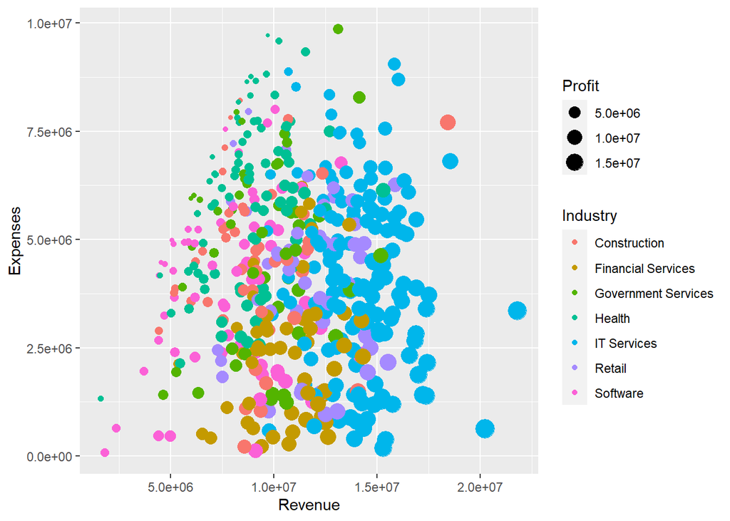

```r
p<-ggplot(data=fin)+ aes(x= Revenue, y= Expenses, size= Profit,colour= Industry)+ geom_point()
p
```

2- a point cloud including the trends of the different industries for the expenditure and income variables. ###################################################################### 2- un nuage de points incluant les tendances des différentes industries pour les variables de dépenses et de revenus.

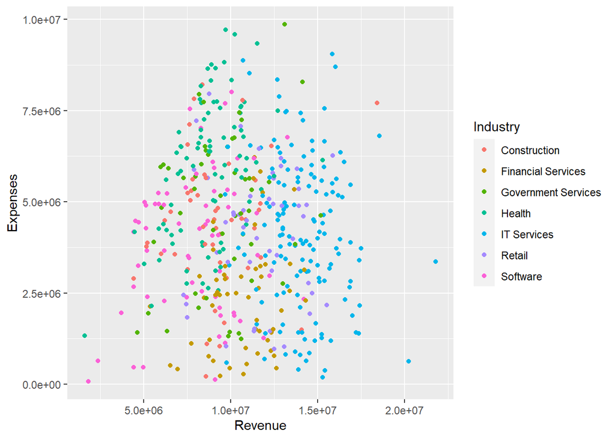

```r
p<-ggplot(data=fin)+ aes(x= Revenue, y= Expenses,colour= Industry)+ geom_point()
p
```

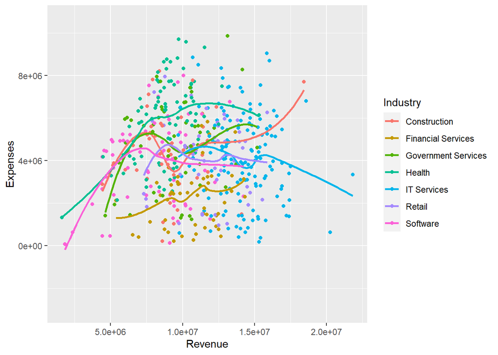

```r
p+geom_smooth(fill= NA, size = 1)
```

geom_smooth allows you to draw trend curves. a Boxplot showing growth by industry. ######################################################################

geom_smooth vous permet de tracer des courbes de tendance. a Boxplot montrant la croissance par industrie. # Boxplot

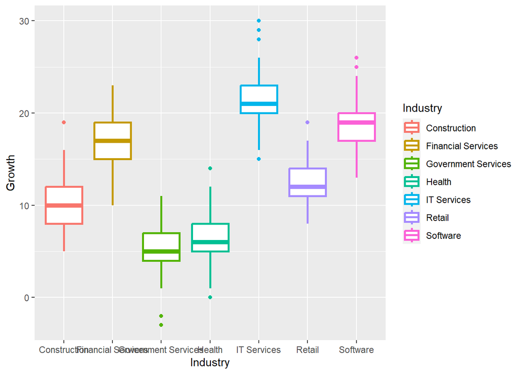

```r
f<-ggplot(data=fin)+ aes(x= Industry, y= Growth, colour = Industry)+ geom_boxplot(size=1)
f
```

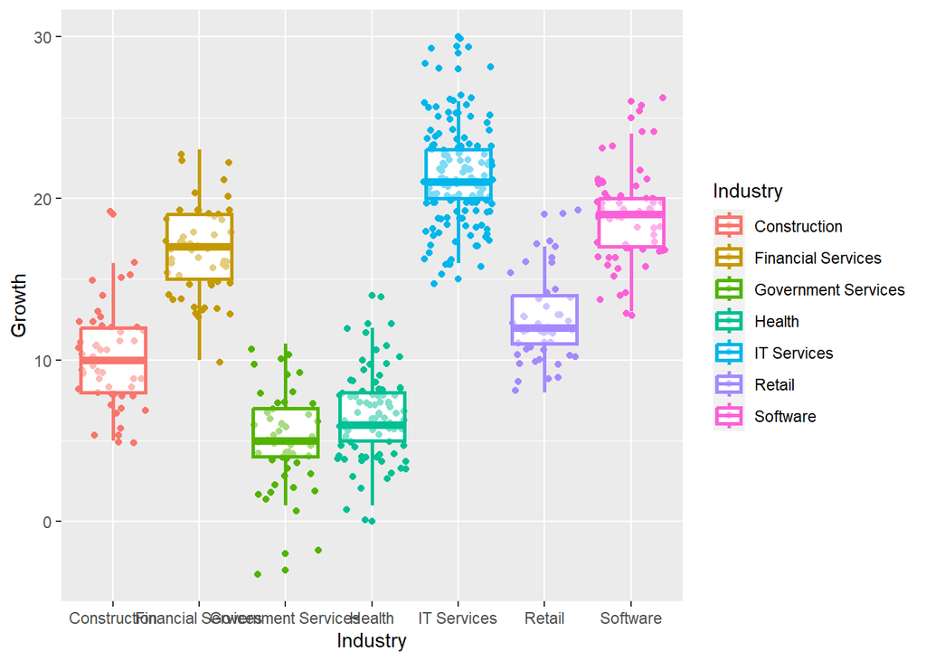

```r
f+geom_jitter()+geom_boxplot(size=1, alpha=0.5, outlier.colour = NA)
```